# Template

2026-06-12

# Title Page

Include your names Melvin Hofman Max Bergsma Gijs Stevens Hidde Voors Imad el Hilali

# Part 1 - Identify a Social Problem

Use APA referencing throughout your document. [Here’s a link to some explanation.](https://www.mendeley.com/guides/apa-citation-guide/)

## 1.1 Describe the Social Problem

Housing affordability has become an increasingly important social issue in the Netherlands over the past decade. House prices have risen substantially in many parts of the country, while income growth may not have kept pace. As a result, many households, particularly first-time buyers and younger generations, face greater difficulties entering the housing market. Rising housing costs can contribute to financial stress, wealth inequality, and reduced access to homeownership.

Understanding whether house prices have increased faster than incomes is therefore important for evaluating changes in housing affordability. If housing prices grow more rapidly than household incomes, purchasing a home becomes increasingly difficult for a large share of the population. This may have significant social and economic consequences, including increased inequality between homeowners and non-homeowners.

The main research question of this study is:

Have housing prices in the Netherlands increased faster than incomes over the past ten years?

# Part 2 - Data Sourcing

## 2.1 Load in the data

Preferably from a URL, but if not, make sure to download the data and store it in a shared location that you can load the data in from. Do not store the data in a folder you include in the Github repository!

```r
# data_download <- cbs_get_data("70072NED")

# raw_dataset <- data_download %>% cbs_add_label_columns()

# write.csv(raw_dataset, "data/raw_dataset.csv")
raw_dataset = read.csv("data/raw_dataset.csv")
```

## 2.2 Provide a short summary of the dataset(s)

```r
huizenprijzen_provincie = raw_dataset %>%
  mutate(
    Year = as.integer(substr(Perioden, 1, 4))
  ) %>%
  filter(
    Year == 2023,
    startsWith(RegioS, "PV")
  ) %>%
  select(
    Year,
    RegioS,
    RegioS_label,
    GemiddeldeWOZWaardeVanWoningen_98
  )
write.csv(huizenprijzen_provincie, "data/huizenprijzen_provincie.csv")

head(huizenprijzen_provincie)
```

|  | Year | RegioS | RegioS_label | GemiddeldeWOZWaardeVanWoningen_98 |
| --- | --- | --- | --- | --- |
| 1 | 2023 | PV20 | Groningen (PV) | 268 |
| 2 | 2023 | PV21 | Fryslân (PV) | 277 |
| 3 | 2023 | PV22 | Drenthe (PV) | 294 |
| 4 | 2023 | PV23 | Overijssel (PV) | 325 |
| 5 | 2023 | PV24 | Flevoland (PV) | 347 |
| 6 | 2023 | PV25 | Gelderland (PV) | 364 |

```r
inkomen_provincie <- raw_dataset %>%
  mutate(
    Year = as.integer(substr(Perioden, 1, 4))
  ) %>%
  filter(
    Year == 2023,
    startsWith(RegioS, "PV")
  ) %>%
  select(
    Year,
    RegioS,
    RegioS_label,
    BronInkomenAlsWerknemer_141
  )
write.csv(inkomen_provincie, "data/inkomen_provincie.csv")

inkomen_provincie
```

| Year | RegioS | RegioS_label | BronInkomenAlsWerknemer_141 |
| --- | --- | --- | --- |
| 2023 | PV20 | Groningen (PV) | 37.5 |
| 2023 | PV21 | Fryslân (PV) | 37.9 |
| 2023 | PV22 | Drenthe (PV) | 39.7 |
| 2023 | PV23 | Overijssel (PV) | 39.5 |
| 2023 | PV24 | Flevoland (PV) | 40.4 |
| 2023 | PV25 | Gelderland (PV) | 40.6 |
| 2023 | PV26 | Utrecht (PV) | 44.4 |
| 2023 | PV27 | Noord-Holland (PV) | 44.7 |
| 2023 | PV28 | Zuid-Holland (PV) | 42.4 |
| 2023 | PV29 | Zeeland (PV) | 40.3 |

[output cut: 2 more lines]

```r
provincie_samengevoegd = huizenprijzen_provincie %>%
  inner_join(
    inkomen_provincie,
    by = c("Year", "RegioS", "RegioS_label")
  ) %>%
  rename(
    GemiddeldeWOZ = GemiddeldeWOZWaardeVanWoningen_98,
    InkomenWerknemer = BronInkomenAlsWerknemer_141
  )  %>%
  mutate(statcode = RegioS)
provincie_samengevoegd
```

| Year | RegioS | RegioS_label | GemiddeldeWOZ | InkomenWerknemer | statcode |
| --- | --- | --- | --- | --- | --- |
| 2023 | PV20 | Groningen (PV) | 268 | 37.5 | PV20 |
| 2023 | PV21 | Fryslân (PV) | 277 | 37.9 | PV21 |
| 2023 | PV22 | Drenthe (PV) | 294 | 39.7 | PV22 |
| 2023 | PV23 | Overijssel (PV) | 325 | 39.5 | PV23 |
| 2023 | PV24 | Flevoland (PV) | 347 | 40.4 | PV24 |
| 2023 | PV25 | Gelderland (PV) | 364 | 40.6 | PV25 |
| 2023 | PV26 | Utrecht (PV) | 447 | 44.4 | PV26 |
| 2023 | PV27 | Noord-Holland (PV) | 460 | 44.7 | PV27 |
| 2023 | PV28 | Zuid-Holland (PV) | 359 | 42.4 | PV28 |
| 2023 | PV29 | Zeeland (PV) | 281 | 40.3 | PV29 |

[output cut: 2 more lines]

```r
provincie_summary = provincie_samengevoegd %>%
  summarise(
    Mean_WOZ = mean(GemiddeldeWOZ),
    Min_WOZ = min(GemiddeldeWOZ),
    Max_WOZ = max(GemiddeldeWOZ),
    SD_WOZ = sd(GemiddeldeWOZ),

    Mean_Income = mean(InkomenWerknemer),
    Min_Income = min(InkomenWerknemer),
    Max_Income = max(InkomenWerknemer),
    SD_Income = sd(InkomenWerknemer),
  ) %>%
  pivot_longer(
    cols = everything(),
    names_to = c("Statistic", "Variable"),
    names_sep = "_",
    values_to = "Value"
  ) %>%
  pivot_wider(
    names_from = Statistic,
    values_from = Value
  ) %>%
  mutate(
    Variable = recode(
      Variable,
      WOZ = "Average WOZ Value",
      Income = "Employee Income",
      Affordability = "WOZ-to-Income Ratio"
    )
  ) %>%
  select(Variable, Mean, Min, Max, SD)

kable(
  provincie_summary,
  caption = "Descriptive statistics for home value in provinces in the Netherlands, 2023",
  digits = 2
)
```

Descriptive statistics for home value in provinces in the Netherlands, 2023

| Variable | Mean | Min | Max | SD |
| --- | --- | --- | --- | --- |
| Average WOZ Value | 340.00 | 268.0 | 460.0 | 64.25 |
| Employee Income | 40.76 | 37.5 | 44.7 | 2.24 |

```r
provincie_samengevoegd <- provincie_samengevoegd %>%
  mutate(
    AffordabilityRatio = GemiddeldeWOZ / InkomenWerknemer
  )
provincie_samengevoegd
```

| Year | RegioS | RegioS_label | GemiddeldeWOZ | InkomenWerknemer | statcode | AffordabilityRatio |
| --- | --- | --- | --- | --- | --- | --- |
| 2023 | PV20 | Groningen (PV) | 268 | 37.5 | PV20 | 7.146667 |
| 2023 | PV21 | Fryslân (PV) | 277 | 37.9 | PV21 | 7.308707 |
| 2023 | PV22 | Drenthe (PV) | 294 | 39.7 | PV22 | 7.405542 |
| 2023 | PV23 | Overijssel (PV) | 325 | 39.5 | PV23 | 8.227848 |
| 2023 | PV24 | Flevoland (PV) | 347 | 40.4 | PV24 | 8.589109 |
| 2023 | PV25 | Gelderland (PV) | 364 | 40.6 | PV25 | 8.965517 |
| 2023 | PV26 | Utrecht (PV) | 447 | 44.4 | PV26 | 10.067568 |
| 2023 | PV27 | Noord-Holland (PV) | 460 | 44.7 | PV27 | 10.290828 |
| 2023 | PV28 | Zuid-Holland (PV) | 359 | 42.4 | PV28 | 8.466981 |
| 2023 | PV29 | Zeeland (PV) | 281 | 40.3 | PV29 | 6.972705 |

[output cut: 2 more lines]

```r
# 2e Nieuwe variable

write.csv(provincie_samengevoegd, "data/provincie_samengevoegd.csv")
```

```r
landelijk <- raw_dataset %>%
  mutate(
    Year = as.integer(substr(Perioden, 1, 4))
  ) %>%
  filter(
    Year >= 2015,
    Year <= 2024,
    startsWith(RegioS, "NL")
  ) %>%
  select(
    Year,
    RegioS_label,
    BronInkomenAlsWerknemer_141,
    GemiddeldeWOZWaardeVanWoningen_98
  ) %>%
  rename(
    GemiddeldeWOZ = GemiddeldeWOZWaardeVanWoningen_98,
    InkomenWerknemer = BronInkomenAlsWerknemer_141
  ) %>%
  mutate(
    AffordabilityRatio = GemiddeldeWOZ / InkomenWerknemer,
    WOZ_growth_yoy = (GemiddeldeWOZ / lag(GemiddeldeWOZ) - 1) * 100,
    Income_growth_yoy = (InkomenWerknemer / lag(InkomenWerknemer) - 1) * 100,
    GrowthGap_yoy = WOZ_growth_yoy - Income_growth_yoy
  )

write.csv(landelijk, "data/landelijk.csv")

landelijk
```

| Year | RegioS_label | InkomenWerknemer | GemiddeldeWOZ | AffordabilityRatio | WOZ_growth_yoy | Income_growth_yoy | GrowthGap_yoy |
| --- | --- | --- | --- | --- | --- | --- | --- |
| 2015 | Nederland | 30.3 | 206 | 6.798680 | NA | NA | NA |
| 2016 | Nederland | 31.4 | 208 | 6.624204 | 0.9708738 | 3.630363 | -2.659489 |
| 2017 | Nederland | 32.0 | 217 | 6.781250 | 4.3269231 | 1.910828 | 2.416095 |
| 2018 | Nederland | 32.3 | 230 | 7.120743 | 5.9907834 | 0.937500 | 5.053283 |
| 2019 | Nederland | 33.7 | 250 | 7.418398 | 8.6956522 | 4.334365 | 4.361287 |
| 2020 | Nederland | 35.3 | 271 | 7.677054 | 8.4000000 | 4.747774 | 3.652226 |
| 2021 | Nederland | 37.1 | 290 | 7.816712 | 7.0110701 | 5.099150 | 1.911920 |
| 2022 | Nederland | 39.0 | 317 | 8.128205 | 9.3103448 | 5.121294 | 4.189051 |
| 2023 | Nederland | 41.8 | 368 | 8.803828 | 16.0883281 | 7.179487 | 8.908841 |
| 2024 | Nederland | 44.7 | 378 | 8.456376 | 2.7173913 | 6.937799 | -4.220408 |

```r
provincie_map <- cbs_get_sf("provincie", 2023, verbose = TRUE)
```

```
## Note that `cbs_add_statcode` can be used for connecting the map to the data.
```

```
## Retrieving list of geojson files: 'https://cartomap.github.io/nl/index.csv'
```

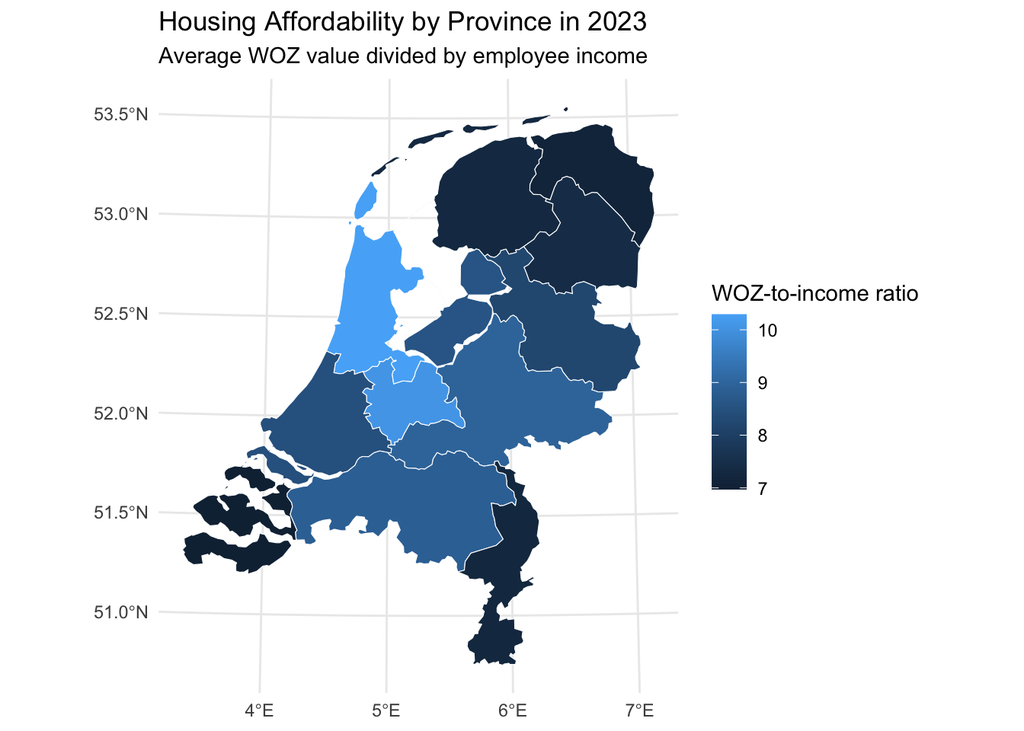

```r
provincie_samengevoegd <- provincie_samengevoegd %>%
  mutate(
    statcode = trimws(RegioS),
    AffordabilityRatio = GemiddeldeWOZ / InkomenWerknemer
  )

provincie_map <- provincie_map %>%
  mutate(
    statcode = trimws(statcode)
  )

provincie_map_data <- provincie_map %>%
  left_join(
    provincie_samengevoegd,
    by = "statcode"
  )

ggplot(provincie_map_data) +
  geom_sf(aes(fill = AffordabilityRatio), color = "white") +
  labs(
    title = "Housing Affordability by Province in 2023",
    subtitle = "Average WOZ value divided by employee income",
    fill = "WOZ-to-income ratio"
  ) +
  theme_minimal()
```

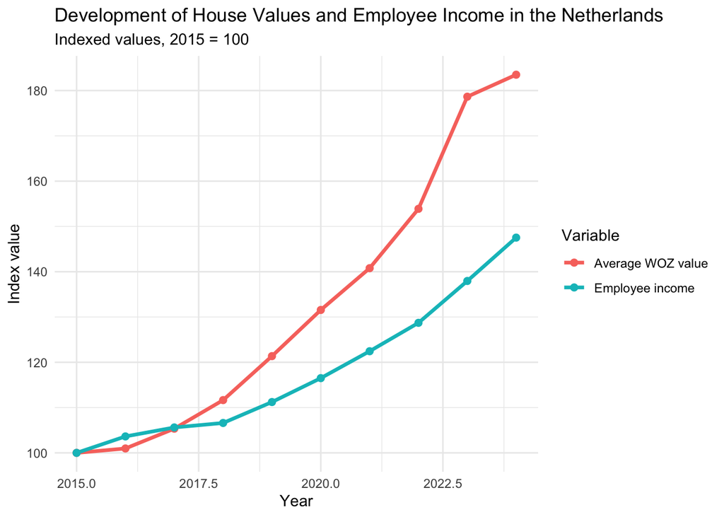

```r
# Deze plot gemaakt met chat

landelijk_index <- landelijk %>%
  arrange(Year) %>%
  mutate(
    WOZ_index = GemiddeldeWOZ / GemiddeldeWOZ[Year == 2015] * 100,
    Inkomen_index = InkomenWerknemer / InkomenWerknemer[Year == 2015] * 100
  ) %>%
  select(Year, WOZ_index, Inkomen_index) %>%
  pivot_longer(
    cols = c(WOZ_index, Inkomen_index),
    names_to = "Variable",
    values_to = "Index"
  ) %>%
  mutate(
    Variable = recode(
      Variable,
      WOZ_index = "Average WOZ value",
      Inkomen_index = "Employee income"
    )
  )

ggplot(landelijk_index, aes(x = Year, y = Index, color = Variable)) +
  geom_line(linewidth = 1.2) +
  geom_point(size = 2) +
  labs(
    title = "Development of House Values and Employee Income in the Netherlands",
    subtitle = "Indexed values, 2015 = 100",
    x = "Year",
    y = "Index value",
    color = "Variable"
  ) +
  theme_minimal()
```

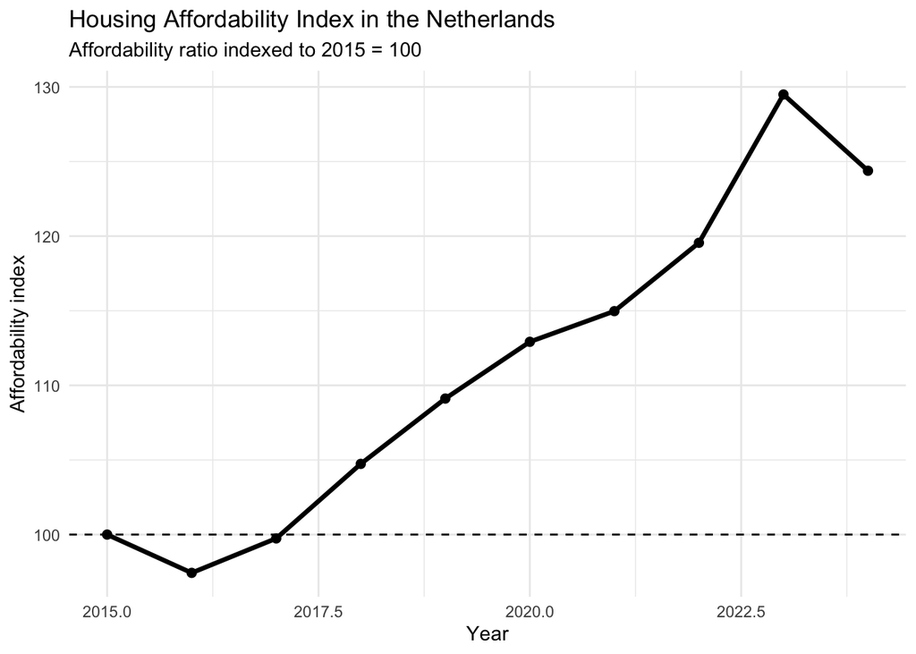

```r
landelijk_affordability_index <- landelijk %>%
  arrange(Year) %>%
  mutate(
    AffordabilityIndex = AffordabilityRatio / AffordabilityRatio[Year == 2015] * 100
  )

ggplot(landelijk_affordability_index, aes(x = Year, y = AffordabilityIndex)) +
  geom_line(linewidth = 1.2) +
  geom_point(size = 2) +
  geom_hline(yintercept = 100, linetype = "dashed") +
  labs(
    title = "Housing Affordability Index in the Netherlands",
    subtitle = "Affordability ratio indexed to 2015 = 100",
    x = "Year",
    y = "Affordability index"
  ) +
  theme_minimal()
```

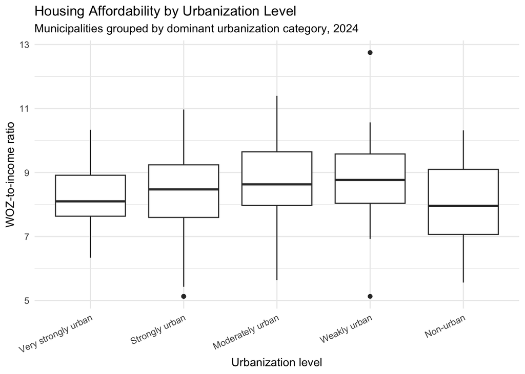

```r
urban_affordability <- raw_dataset %>%
  mutate(
    Year = as.integer(substr(Perioden, 1, 4))
  ) %>%
  filter(
    Year == 2024,
    startsWith(RegioS, "GM")
  ) %>%
  select(
    Year,
    RegioS,
    RegioS_label,
    GemiddeldeWOZWaardeVanWoningen_98,
    BronInkomenAlsWerknemer_141,
    ZeerSterkStedelijk_52,
    SterkStedelijk_53,
    MatigStedelijk_54,
    WeinigStedelijk_55,
    NietStedelijk_56
  ) %>%
  rename(
    GemiddeldeWOZ = GemiddeldeWOZWaardeVanWoningen_98,
    InkomenWerknemer = BronInkomenAlsWerknemer_141
  ) %>%
  mutate(
    AffordabilityRatio = GemiddeldeWOZ / InkomenWerknemer
  ) %>%
  pivot_longer(
    cols = c(
      ZeerSterkStedelijk_52,
      SterkStedelijk_53,
      MatigStedelijk_54,
      WeinigStedelijk_55,
      NietStedelijk_56
    ),
    names_to = "UrbanizationType",
    values_to = "UrbanizationValue"
  ) %>%
  group_by(RegioS, RegioS_label, Year) %>%
  slice_max(UrbanizationValue, n = 1, with_ties = FALSE) %>%
  ungroup() %>%
  mutate(
    UrbanizationType = recode(
      UrbanizationType,
      ZeerSterkStedelijk_52 = "Very strongly urban",
      SterkStedelijk_53 = "Strongly urban",
      MatigStedelijk_54 = "Moderately urban",
      WeinigStedelijk_55 = "Weakly urban",
      NietStedelijk_56 = "Non-urban"
    ),
    UrbanizationType = factor(
      UrbanizationType,
      levels = c(
        "Very strongly urban",
        "Strongly urban",
        "Moderately urban",
        "Weakly urban",
        "Non-urban"
      )
    )
  )

ggplot(urban_affordability, aes(x = UrbanizationType, y = AffordabilityRatio)) +
  geom_boxplot() +
  labs(
    title = "Housing Affordability by Urbanization Level",
    subtitle = "Municipalities grouped by dominant urbanization category, 2024",
    x = "Urbanization level",
    y = "WOZ-to-income ratio"
  ) +
  theme_minimal() +
  theme(
    axis.text.x = element_text(angle = 25, hjust = 1)
  )
```

```r
inline_code = TRUE
```

These are things that are usually included in the metadata of the dataset. For your project, you need to provide us with the information from your metadata that we need to understand your dataset of choice.

## 2.3 Describe the type of variables included

Think of things like:

- Do the variables contain health information or SES information?
- Have they been measured by interviewing individuals or is the data coming from administrative sources?

*For the sake of this example, I will continue with the assignment…*

# Part 3 - Quantifying

## 3.1 Data cleaning

```r
#mean(dataset$percollege)
```

Please use a separate ‘R block’ of code for each type of cleaning. So, e.g. one for missing values, a new one for removing unnecessary variables etc.

## 3.6 Event analysis

Analyze the relationship between two variables.

# Part 4 - Discussion

## 4.1 Discuss your findings

# Part 5 - Reproducibility

## 5.2 Reference list

Use APA referencing throughout your document.